# Transition & Duration Models - Homework: Replication Study of Lalive et al. (2006)

Marcel Richard Penda

2024-04-10

# Setup

## Libraries

```r
#Loading packages
library(pacman)
p_load(foreign, tidyverse, survival, KernSmooth,
       tidyverse, data.table, broom, parallel, here, plotly, ggplot2, stargazer, magrittr,skimr,janitor,  tidymodels, ADAPTS, caret, yardstick, rlang, parsnip, sandwich, lmtest, haven, tinytex, rdrobust,dplyr, plotrix, plyr,readxl, usmap, stringr, finalfit, scales,tidyr, gridExtra, patchwork, EventStudy, fixest,kableExtra,wesanderson, gtsummary, maps, cowplot, corrplot, ggcorrplot, ggthemes, wesanderson, mgcv, lmtest)

# Set working directory
setwd("C:/Users/marce/OneDrive - UT Cloud/03_Semester - Marseille (WiSe23_SoSe24)/14_Transition & Duration Models/05_Midterm Replication Study")

# Deactivate scientific notation
options(scipen = 999)
```

## Read Data

```r
unemp <- read.dta("fi.dta")
unemp <- unemp[,1:134] ## get rid of some superfluous variables
unemp <- as_tibble(unemp)
head(unemp)
```

```
## # A tibble: 6 × 134
##   beginn ein_zus sfrau   age after   dur nwage_pj  e3_5  bdur y1988 y1989 y1990
##    <dbl>   <dbl> <dbl> <dbl> <dbl> <dbl>    <dbl> <dbl> <dbl> <dbl> <dbl> <dbl>
## 1  10412       0     0  51.1     0 0.143   11283.     1    30     1     0     0
## 2  10169       0     1  54.7     0 0.143    8578.     1    30     0     0     0
## 3  10624       0     1  54.0     0 0.143    6828.     1    30     0     1     0
## 4  10343       0     0  54.1     0 0.143   10072.     0    20     1     0     0
## 5  10654       0     0  46.1     0 0.143    6342.     1    30     0     1     0
## 6  10101       0     0  42.1     0 0.143    6094.     1    30     0     0     0
## # ℹ 122 more variables: y1991 <dbl>, med_educ <dbl>, hi_educ <dbl>,
## #   lehre <dbl>, married <dbl>, single <dbl>, divorced <dbl>, f_marr <dbl>,
## #   f_single <dbl>, f_divor <dbl>, bc <dbl>, pnon_10 <dbl>, q2 <dbl>, q3 <dbl>,
## #   q4 <dbl>, seasonal <dbl>, manuf <dbl>, ten72 <dbl>, type <fct>, uncc <dbl>,
## #   lwage <dbl>, tr <dbl>, t39 <dbl>, t52 <dbl>, t39_tr <dbl>, t52_tr <dbl>,
## #   after0 <dbl>, tr_a0 <dbl>, t39_a0 <dbl>, t52_a0 <dbl>, t39tra0 <dbl>,
## #   t52tra0 <dbl>, after1 <dbl>, tr_a1 <dbl>, t39_a1 <dbl>, t52_a1 <dbl>, …
```

# Q1: Summary of the Paper

Following the policy regulation, the authors categorize the individuals based on the determinants (i.e. age, income, and experience) of the RR and PBD eligibility, resulting in four different groups of unemployed workers:

1. Eligible for PDB: Older individuals (threshold at age 40) earning more than 12,610 ATS and with high experience.
2. Eligible for increase in RR: Young (and older) unemployed individuals earning less than 12,610 ATS with low and high experience (with low experience).
3. Eligible for PDB and increase in RR: Older individuals earning less than than 12,610 ATS with high experience.
4. Control group: Young (and older) unemployed individuals earning more than 12,610 ATS with low and high experience (with low experience).

Consequently, we have heterogeneity in treatment and in the treatment magnitude since the RR and PDB increases are not comparable. Due to additional unemployment benefits for regions dominated by the steel industry, the study concentrates on non-steel industry regions only. Based on this data, the authors first conduct a simple difference-in-difference analysis and estimate the survivor functions as well as exit hazards for the different groups of workers. The key results of their study come from the estimation of a piecewise exponential model (PWE) measuring the treatment effects for different time intervals.

The authors find that an increase in the RR effects the rates of exiting the state of unemployment at the beginning, whereas the effect of extended PBD occurs especially arround the expiration dates of the PBD. Moreover, older individuals are more effected by the PBD and the combined disincentives. Furthermore, the PWE shows that the treatment effects are different for different intervals.

One of the study’s main contributions is the understanding of unemployment incentives. More precisely, the authors conclude that for policy makers to influence/reduce unemployment rates, the PBD represents a more effective tool compared to the RR. Moreover, with their study the authors provide empirical evidence for exiting theoretical labor economic models. While these models provide predictions only about the sign/directions of unemployment incentives, these results provide indication about how large these effects are.

However, before 1989 the Austrian unemployment benefits were rather low compared to other European countries, making the results difficult to transfer to other countries.

# Q2: Difference-in-Differences Analysis

To replicate the authors’ difference-in-differences results, we prepare our dependent variable, i.e. durations in weeks, such that our data is right-censored after 104 weeks. Put differently, all duration values exceeding 104 weeks are set to the duration of 104 weeks such that we obtain a right-censored subsample.

```r
# Computation of average spells when durations are truncated at 104 weeks
unemp %>%
  mutate(dur104 = dur,
         dur104 = ifelse(dur104 > 104, 104, dur104)) -> unemp
```

In a next step, we calculate the difference-in-differences estimator:
$$\hat{\Delta}_{DD} = (Y^T_A - Y^T_B) - (Y_A^C - Y_B^C) \\ \; \text{where}
\; Y^T_A \; \text{and} \; Y^T_B \; \text{denote the average unemployment
duration of the treated group} \\ \text{and} \; Y_A^C \; Y_B^C \;
\text{denote the average unemployment duration of the control group}$$

To do so, we first compute the average unemployment duration for all treated groups and the control sample. Based on the latter the difference-in-differences estimator is estimated

```r
# Create objects with group names
group <- c("PBD", "RR",  "PBD and RR")
group_se <- c("PBD SE", "RR SE", "PBD and RR SE")
group_names <- c("PBD", "PBD SE", "RR", "RR SE", "PBD and RR", "PBD and RR SE", "control", "control SE")

# Initialize DiD_table with appropriate dimensions
DiD_table <- data.frame(matrix(nrow = length(group_names), ncol = 5))
colnames(DiD_table) <- c("Group", "Before 1989", "After 1989", "Change", "Diff-in-Diff")
DiD_table$Group <- group_names

# Average duration for control
Y_CB <- mean(unemp$dur104[unemp$type == "control" & unemp$after == 0])
Y_CA <- mean(unemp$dur104[unemp$type == "control" & unemp$after == 1])
change_control <- Y_CA - Y_CB

# standard errors for control group
se_Y_CB <- sd(unemp$dur104[unemp$type == "control" & unemp$after == 0])/sqrt(length(unemp$dur104[unemp$type == "control" & unemp$after == 0]))
se_Y_CA <- sd(unemp$dur104[unemp$type == "control" & unemp$after == 1])/sqrt(length(unemp$dur104[unemp$type == "control" & unemp$after == 1]))
se_change_control <- sqrt(se_Y_CB^2 + se_Y_CA^2)

# values for control group
values_control <- c(Y_CB, Y_CA, change_control, NA)
se_control <- c(se_Y_CB, se_Y_CA, se_change_control, NA)

# Assign control group values to the corresponding row in DiD_table
DiD_table[DiD_table$Group == "control", -1] <- values_control
DiD_table[DiD_table$Group == "control SE", -1] <- se_control

# Calculate values for different groups
for (i in group) {
  # Calculate values for different groups
  Y_TB <- mean(unemp$dur104[unemp$type == i & unemp$after == 0])
  Y_TA <- mean(unemp$dur104[unemp$type == i & unemp$after == 1])
  change_var <- Y_TA - Y_TB
  did_var <- change_var - change_control

  # calculate standard errors
  se_Y_TB <- sd(unemp$dur104[unemp$type == i & unemp$after == 0])/sqrt(length(unemp$dur104[unemp$type == i & unemp$after == 0]))
  se_Y_TA <- sd(unemp$dur104[unemp$type == i & unemp$after == 1])/sqrt(length(unemp$dur104[unemp$type == i & unemp$after == 1]))
  se_change_var <- sqrt(se_Y_TB^2 + se_Y_TA^2)
  se_did <- sqrt(se_change_var^2 + se_change_control^2)

  # Values for variables and standard erros
  values_var <- c(Y_TB,  Y_TA,  change_var,  did_var)
  se_var <- c(se_Y_TB, se_Y_TA, se_change_var, se_did)

  # Assign values to corresponding group in DiD_table
  DiD_table[DiD_table$Group == i, -1] <- values_var
  DiD_table[DiD_table$Group == paste(i, "SE", sep = " "), -1] <- se_var
}

print(DiD_table)
```

```
##           Group Before 1989  After 1989    Change Diff-in-Diff
## 1           PBD 15.83402138 18.08297903 2.2489577    1.0795374
## 2        PBD SE  0.07572010  0.09118705 0.1185268    0.1665300
## 3            RR 17.10815307 19.09595600 1.9878029    0.8183827
## 4         RR SE  0.11795657  0.15225308 0.1926000    0.2253406
## 5    PBD and RR 18.48832242 22.73973032 4.2514079    3.0819876
## 6 PBD and RR SE  0.16178444  0.23300208 0.2836621    0.3068351
## 7       control 14.46225724 15.63167752 1.1694203           NA
## 8    control SE  0.07823008  0.08696947 0.1169771           NA
```

# Q3: Survival Function

$$\hat{S}(t) = \prod_{r=1}^{n} \frac{N_r-E_r}{N_r} \\
\text{where} \; N_r \; \text{denotes the number of observations in the
risk set for the interval} \; r \; \\
\text{and} \; E_r \; \text{denotes the number of observations exiting
the the risk set in the interval}.$$

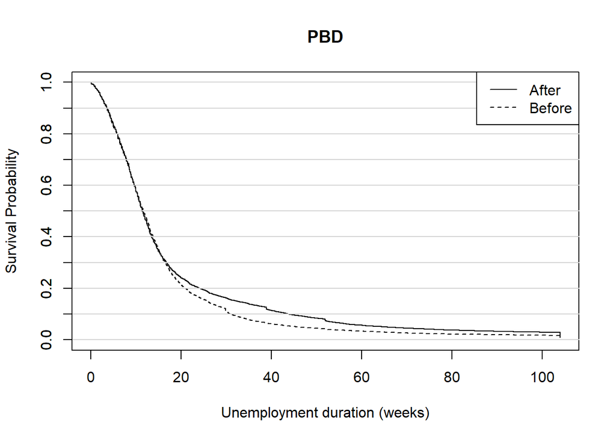

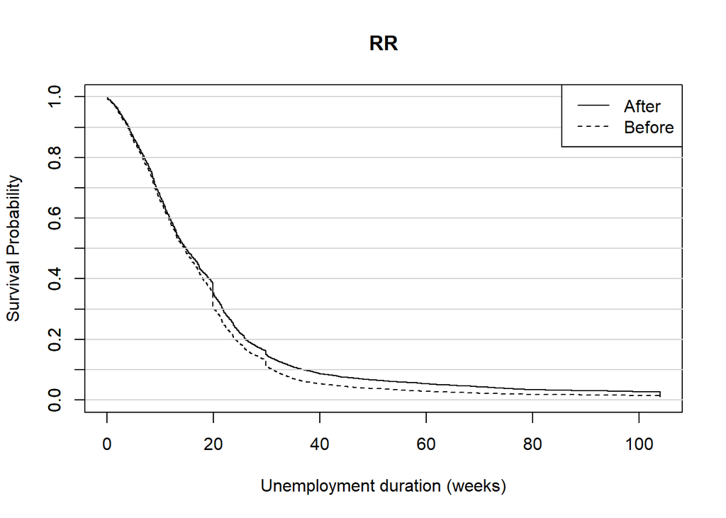

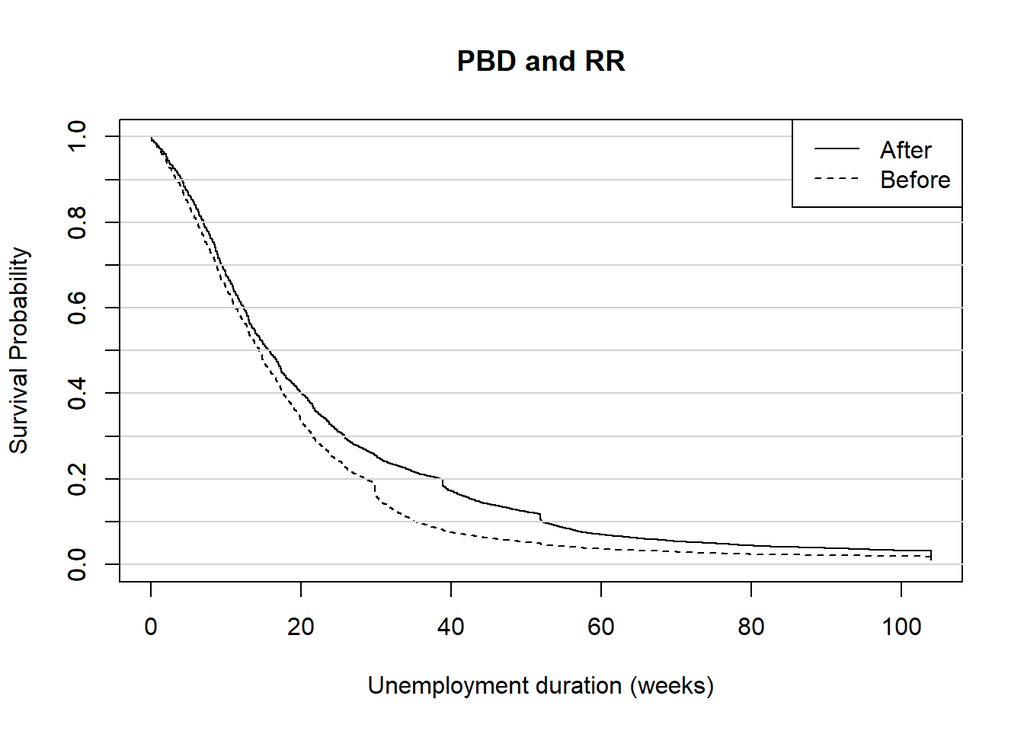

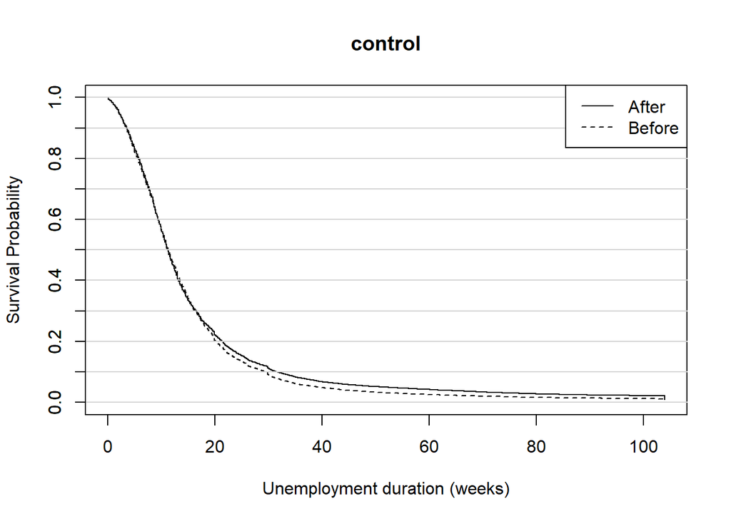

```r
options(repr.plot.width = 6, repr.plot.height =15)
group <- c("PBD", "RR", "PBD and RR", "control")
for (i in group) {
  # survival function after 1989
  plot(survfit(Surv(dur104, uncc) ~ 1, # do not include any covariates
                     conf.int = 0, # do not show confidence intervals
                     data = unemp[unemp$type == i & unemp$after == 1, ]),
       main = i,
       xlab = "Unemployment duration (weeks)",
       ylab = "Survival Probability",
       lty = "solid")

  # survival function before 1989
  lines(survfit(Surv(dur104, uncc) ~ 1, # do not include any covariats
                conf.int = 0, # do not show confidence intervals
                data = unemp[unemp$type == i & unemp$after == 0, ]),
        lty = "dashed")

  # horizontal lines
  abline(h = seq(0, 1, by = 0.1), col = "lightgray", lty = "solid")

  # Change ticks on axis
  axis(side = 2, at = seq(0, max(1), by = 0.1))


  # Include legend
  legend("topright", legend = c("After", "Before"), lty = c("solid", "dashed"))
}
```

The survival functions of the control group before and after the policy implementation show almost no differences.This suggests that workers who were not disincentivized by any increase in the potential duration of unemployment benefits (PBD), higher replacement rates (RR), or both (PBD+RR) did not change their job search behavior.

# Q4: KM estimates of the unemployment exit hazard

$$\lambda = -\frac{d\ln(1-F(t))}{dt}$$

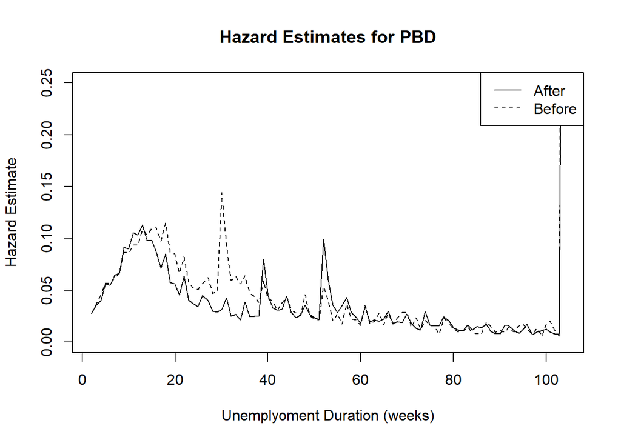

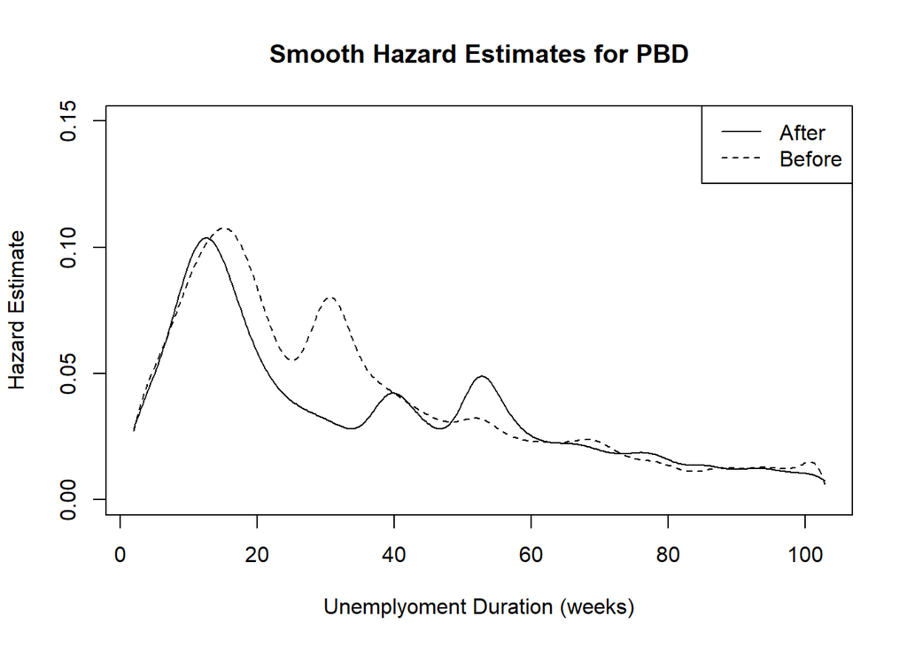

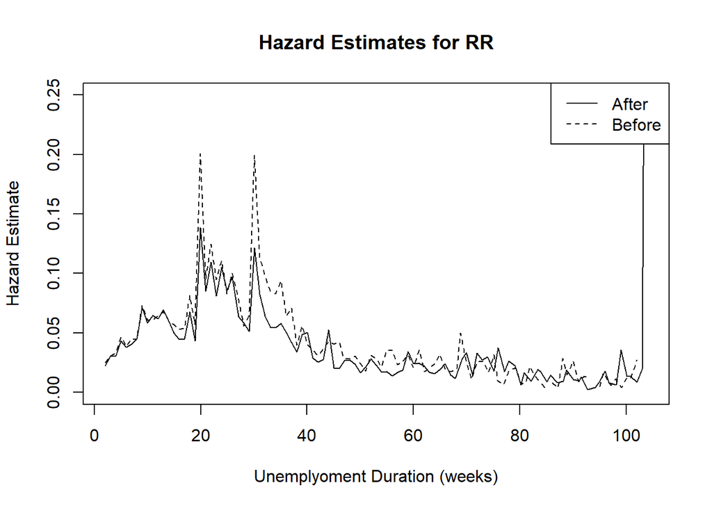

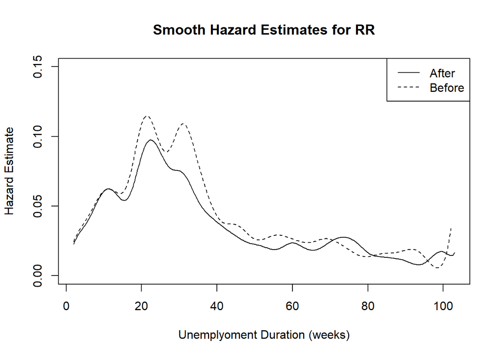

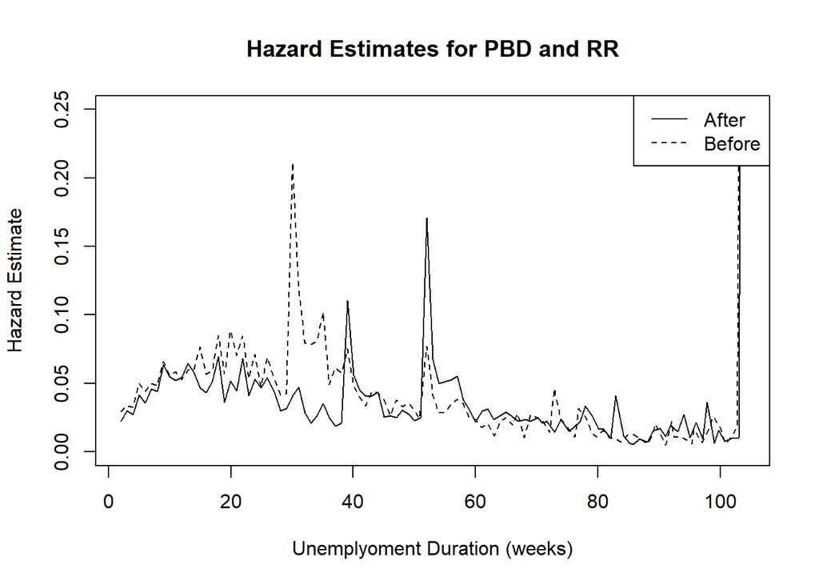

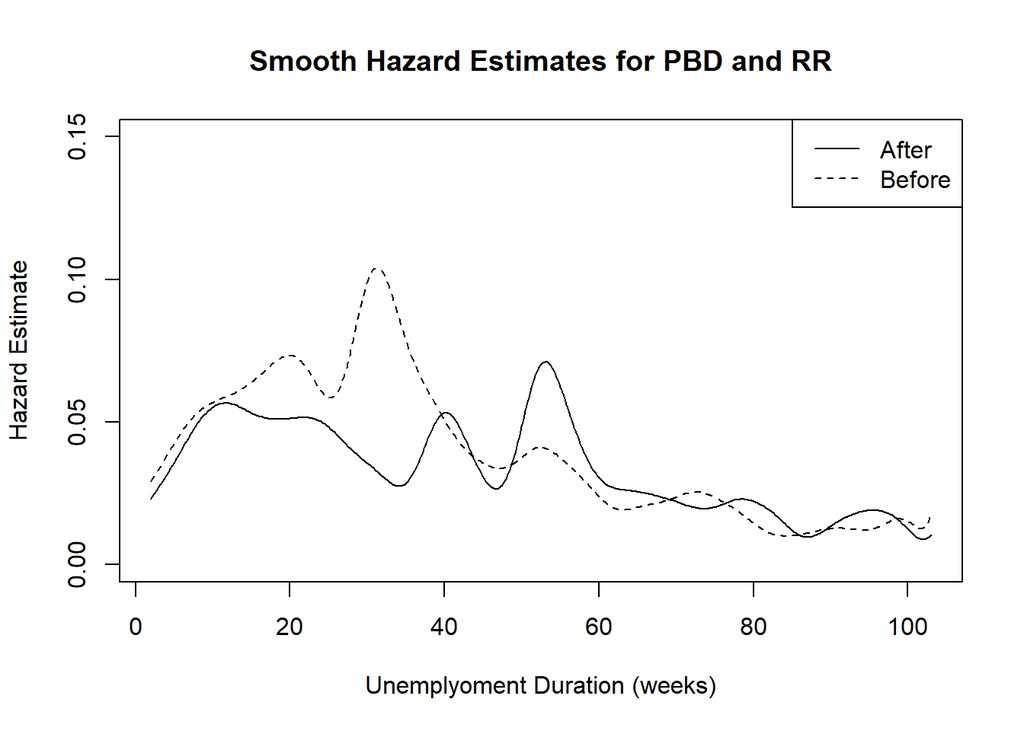

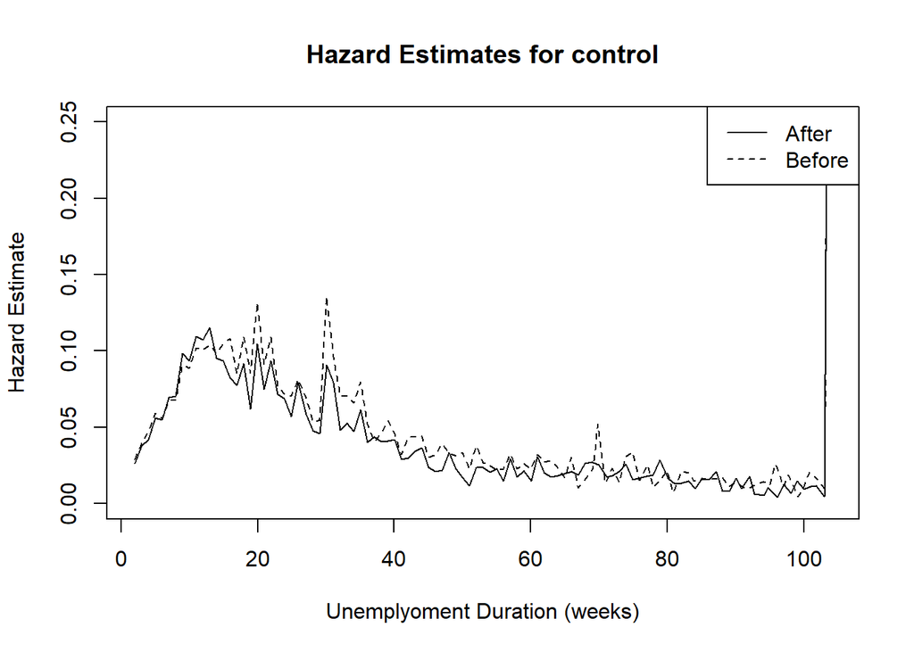

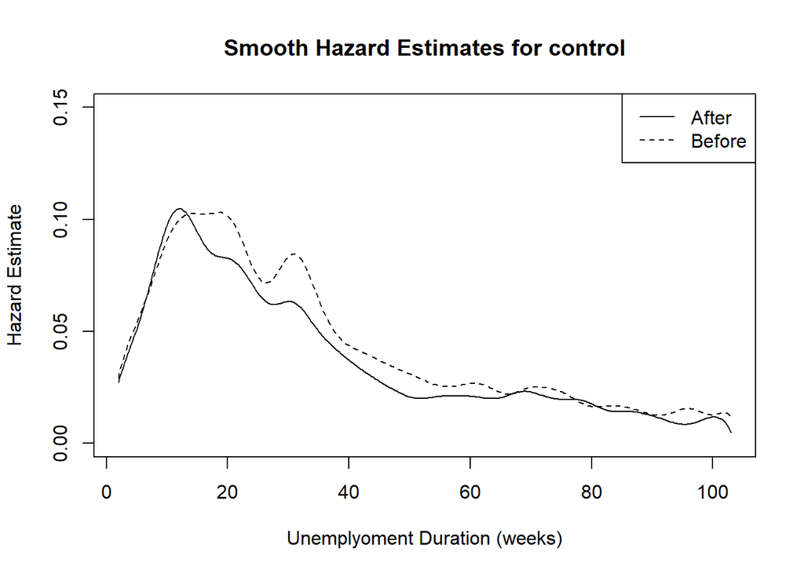

```r
# Initiate objects containing groups and indicator for policy implementation
groups <- c("PBD", "RR", "PBD and RR", "control")
policy = c(0,1)

par(mfrow = c(1,1))

for (group in groups){
  for (state in policy){
    km_fit <- survfit(Surv(dur104, uncc) ~ 1, # do not include any covariates
                       conf.int = 0, # do not show confidence intervals
                       data = unemp[unemp$type == group & unemp$after == state, ])
    km_summary <- summary(km_fit)

    # To make discrete function less erratic, pick smaller number of points, here one for each week
    ## Calculate the number of weeks
    num_weeks <- ceiling(max(km_summary$time))

    ## Initialize vectors to store selected survival probabilities and time points
    surv_prob <- numeric(num_weeks)
    time_pts <- numeric(num_weeks)

    ## Select one value per week
      for (week in 1:num_weeks) {
      # Find the closest time point to the current week
      time_point <- km_summary$time[which.min(abs(km_summary$time - week))]

      # Find the index of the closest time point
      index <- which(km_summary$time == time_point)

      # Store the selected survival probability and time point
      surv_prob[week] <- km_summary$surv[index]
      time_pts[week] <- time_point
      assign(paste("time_", state, sep = ""), time_pts)

      # Calculate the hazards
      hazard <- -diff(log(surv_prob)) / diff(time_pts)
      assign(paste("hazard_", state, sep = ""), hazard)
      }
  }

  # Plotting the hazard functions
  ## Replicating Figure 4 in Lalive et al. (erratic graphs)
  plot(time_1[-1], hazard_1, type = "l",
       main = paste("Hazard Estimates for", sep = " ", group),
       xlab = "Unemplyoment Duration (weeks)",
       ylab = "Hazard Estimate",
       ylim = c(0, 0.25))
  lines(time_0[-1], hazard_0, lty = "dashed")
  ### Include legend
  legend("topright", legend = c("After", "Before"), lty = c("solid", "dashed"))


  ## Replicating grpahs from [Christian Schluter’s] M2 project (smoothed graphs)
  ### KernSmooth::locpoly cannot handle NAs, replace NAs with hazard mean
  #### To avoid "Inf" values at the end of the hazard vector
  hazard_1 <- hazard_1[-(length(hazard_1))] # exclude last hazard value which is "Inf"
  hazard_0 <- hazard_0[-(length(hazard_0))] # exclude last hazard value which is "Inf"


  ### Calculate the mean of non-NA values
  mean_hazard_1 <- mean(hazard_1, na.rm = TRUE)
  mean_hazard_0 <- mean(hazard_0, na.rm = TRUE)
  ## Replace NA values with the mean
  hazard_1[is.na(hazard_1)] <- mean_hazard_1
  hazard_0[is.na(hazard_0)] <- mean_hazard_0

  ### Define polynomial models of degree 3
  poly_model_1 = locpoly(time_1[-c(1, length(time_1))], # exclude last time value, respectively
               hazard_1,
               degree = 3,
               bandwidth=3)

  poly_model_0 = locpoly(time_0[-c(1, length(time_0))], # exclude last time value, respectively
               hazard_0,
               degree = 3,
               bandwidth=3)

  ### Plot the polynomial functions
  plot(poly_model_1$x, poly_model_1$y, type = "l",
       main = paste("Smooth Hazard Estimates for", sep = " ", group),
       xlab = "Unemplyoment Duration (weeks)",
       ylab = "Hazard Estimate",
       ylim = c(0, 0.15))
  lines(poly_model_0$x, poly_model_0$y, lty = "dashed")
  legend("topright", legend = c("After", "Before"), lty = c("solid", "dashed"))
}
```

# Q5: Estimte the causal treatment effect in a PH model

The Proportional Hazard (PH) model incoroporates time-invariant covariates such as sex or ethnicity by conditioning on them. One approach to account for these covariate effect, i.e. individual characteristics that impact the hazard but do not change over time, is the Cox’s PH model:

$$\lambda(t;x) = K(x)\;\lambda_0(t) \; \\ \text{where} \; \lambda_0(t) \;
\text{denotes the baseline hazard common to all observations}, \\
x \; \text{denotes a vetor of covariates}, \\
\text{and K(.) describes the effect of} \; x \; \text{on the baseline
hazard}.$$
In Lalive et al.(2006) the baseline duration dependence is of central interest since it captures the exit rate for an homogeneous group of workers. The authors allow the duration dependence to shift in every four-week interval. To do so, we split the data into four-weeks intervals and consider the intervals as stand-alone explanatory as well as interction variable.

Splitting data into intervals

```r
# Create variable indicating if any policy change (PBD, RR, or PBD+RR) apply to observation
unemp %>%
  mutate(all = tr*(t39+t52)) -> unemp

# Define the breaks for the four-week interval
breaks <- seq(from=3,to=59, by=4)

# Create labels for the intervals
labels <- paste("(", c(0,breaks), ",", c(breaks,104), "]",sep="")

# Create split data set at specified times
usplit <- survSplit(Surv(dur104, uncc)~., # uncc is the censoring indicator
                    data = unemp,
                    cut = breaks, # cut data at predfined breaks
                    end = "time", # defined name of event time variable
                    start = "start", # define name of start time variable
                    event = "nonjob_exit", # name of censoring indicator
                    episode = "interval" # define name of episode variable
                    )

# Create new variable exposure indicating the duration and interval
usplit %>%
  mutate(duration = time - start, # create duration variable
        interval = factor(interval+1, # given intervals are complete intervals, i.e. add one to obtain the started interval
                          labels = labels)) ->  usplit
```

Estimating Piecewise Proportional Hazard Model (Treatment Effects) using the above-mentioned Cox’s PH model.

```r
pwe <- coxph(Surv(duration, nonjob_exit)
             ~ age
             + single
             + married
             + divorced
             + sfrau
             + f_marr
             + f_single
             + f_divor
             + lehre
             + med_educ
             + hi_educ
             + bc
             + lwage
             + ten72
             + pnon_10
             + seasonal
             + manuf
             + y1988
             + y1989
             + y1990
             + y1991
             + q2
             + q3
             + q4
             + interval # duration dependence
             + interval * tr
             + interval * t39
             + interval * t52
             + interval * all
             + interval * after
             # Treatment effects (alternatively use the seperate variables)
             + interval * tr * after
             + interval * t39 * after
             + interval * t52 * after
             + interval * t39 * tr * after
             + interval * t52 * tr * after,
             data = usplit
              )
```

Results

```r
stargazer(pwe,
          dep.var.caption = "", dep.var.labels = "",
          omit.table.layout = "n", star.cutoffs = NA,
          keep.stat = c("n", "ll"), no.space = TRUE,
          header = FALSE,
          title = "PWE Model Results (Treatment Effects)", type = "text"
)
```

```
##
## PWE Model Results (Treatment Effects)
## ============================================
##
## --------------------------------------------
## age                               -0.013
##                                  (0.001)
## single                            0.019
##                                  (0.019)
## married                           0.155
##                                  (0.018)
## divorced                          -0.109
##                                  (0.020)
## sfrau                             -0.047
##                                  (0.024)
## f_marr                            -0.068
##                                  (0.025)
## f_single                          0.137
##                                  (0.027)
## f_divor                           0.053
##                                  (0.027)
## lehre                             -0.045
##                                  (0.005)
## med_educ                          -0.162
##                                  (0.011)
## hi_educ                           -0.262
##                                  (0.012)
## bc                                0.413
##                                  (0.007)
## lwage                             0.119
##                                  (0.008)
## ten72                             -0.005
##                                  (0.001)
## pnon_10                           -0.062
##                                  (0.013)
## seasonal                          0.374
##                                  (0.005)
## manuf                             -0.112
##                                  (0.006)
## y1988                             0.061
```

[output cut: 416 more lines]

```
##                                  (0.352)
## interval(43,47]:tr:t52:after      -0.073
##                                  (0.354)
## interval(47,51]:tr:t52:after      -0.198
##                                  (0.392)
## interval(51,55]:tr:t52:after      0.478
##                                  (0.311)
## interval(55,59]:tr:t52:after      0.117
##                                  (0.376)
## interval(59,104]:tr:t52:after     0.317
##                                  (0.192)
## --------------------------------------------
## Observations                    1,057,906
## Log Likelihood                -2,898,033.000
## ============================================
```